# Tarea - S10 - Frecuencias Relativas

Cabeto

14/7/2020

```r
library(MASS)
df <- birthwt
```

Preguntas de esta tarea 1. Utiliza str() y head() para explorar la estructura, y con help(), mirar el significado de cada variable.

```r
str(df)
```

```
## 'data.frame':    189 obs. of  10 variables:
##  $ low  : int  0 0 0 0 0 0 0 0 0 0 ...
##  $ age  : int  19 33 20 21 18 21 22 17 29 26 ...
##  $ lwt  : int  182 155 105 108 107 124 118 103 123 113 ...
##  $ race : int  2 3 1 1 1 3 1 3 1 1 ...
##  $ smoke: int  0 0 1 1 1 0 0 0 1 1 ...
##  $ ptl  : int  0 0 0 0 0 0 0 0 0 0 ...
##  $ ht   : int  0 0 0 0 0 0 0 0 0 0 ...
##  $ ui   : int  1 0 0 1 1 0 0 0 0 0 ...
##  $ ftv  : int  0 3 1 2 0 0 1 1 1 0 ...
##  $ bwt  : int  2523 2551 2557 2594 2600 2622 2637 2637 2663 2665 ...
```

```r
head(df)
```

```
##    low age lwt race smoke ptl ht ui ftv  bwt
## 85   0  19 182    2     0   0  0  1   0 2523
## 86   0  33 155    3     0   0  0  0   3 2551
## 87   0  20 105    1     1   0  0  0   1 2557
## 88   0  21 108    1     1   0  0  1   2 2594
## 89   0  18 107    1     1   0  0  1   0 2600
## 91   0  21 124    3     0   0  0  0   0 2622
```

```r
#help(birthwt)
```

This data frame contains the following columns:

low : indicator of birth weight less than 2.5 kg.

age : mother’s age in years.

lwt : mother’s weight in pounds at last menstrual period.

race : mother’s race (1 = white, 2 = black, 3 = other).

smoke : smoking status during pregnancy.

ptl : number of previous premature labours.

ht : history of hypertension.

ui : presence of uterine irritability.

ftv : number of physician visits during the first trimester.

bwt : birth weight in grams.

2. Calcula una tabla de frecuencias relativas marginales de los pares (raza de la madre, peso inferior a 2.5 kg o no) que permita ver si la raza de la madre influye en el peso del bebé.

```r
#t_df <- apply(df, MARGIN = 2, FUN = table)
t_df <- table(df[c(1,4)])
t_df
```

```
##    race
## low  1  2  3
##   0 73 15 42
##   1 23 11 25
```

3, Dibuja un diagrama de mosaico de la tabla del ejercicio anterior.

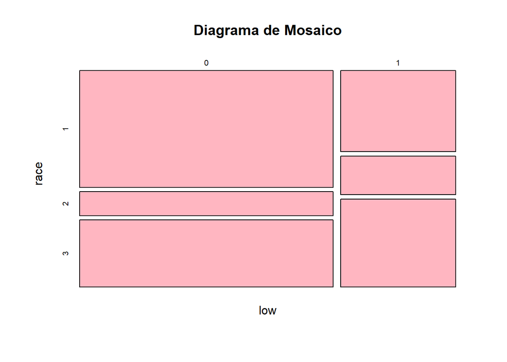

```r
plot(t_df, col = c("lightpink"), main = "Diagrama de Mosaico")
```

4, Dibuja un diagrama bidimensional de barras, con las barras organizadas en bloques, que permita visualizar la información de los ejercicios anteriores. Aprovecha para nombres adecuados a los bloques, colores a las barras, y añadir una leyenda que explique qué representa cada barra.

[figure not shown]

```r
barplot(prop.table(t_df), ylim = c(0, 0.9),
        main = "Frecuencias relativas de la raza de la mujer",
        col = c("lightblue", "lightpink")
        ,  names.arg = c("Blanca", "Negra", "Otro")

        )
legend(x = "topright", legend = c("Bajo Peso","Peso Normal"), fill = c("lightblue", "lightpink"),
       title = "Peso Bebe")
```

5. ¿Se puede obtener alguna conclusión de la tabla y el diagrama de barras anterior? Argumenta tu respuesta